# Datos en áreas

Juan Sebastián Mendoza Páez

2022-06-25

# Modelación de datos en áreas

## Introducción

### Dataset

Se utilizará los datos de censo para 8 condados centrales del estado de New York

```r
library(sf)
library(dplyr)

ny <- st_read('data/NY8_utm18.shp')
```

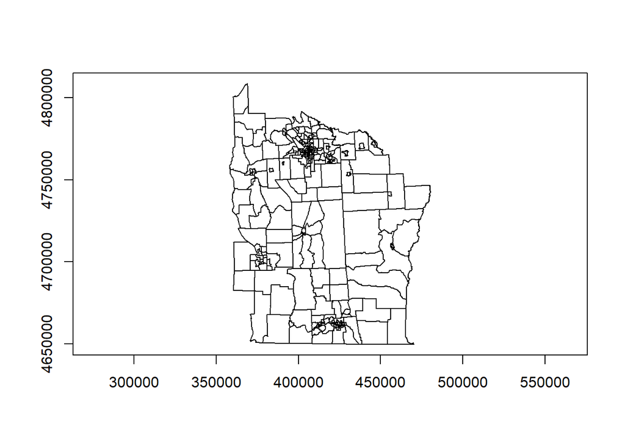

```r
plot(st_geometry(ny), axes = T)
```

# Vecinos y pesos espaciales

# Objeto vecinos

Un archivo `gal` es una matriz de pesos o vecinos producida por el software GeoDa.

```r
library(spdep)

NY_nb <- read.gal('data/NY_nb.gal', # read.gal carga el archivo de clase nb
                  region.id = as.numeric(row.names(ny))-1) # Debe empezar en 0

Syracuse <- filter(ny, AREANAME == 'Syracuse city')
Sy0_nb <- subset(NY_nb, ny$AREANAME == 'Syracuse city')
```

Se realiza un subset del área de trabajo por temas de simplicidad.

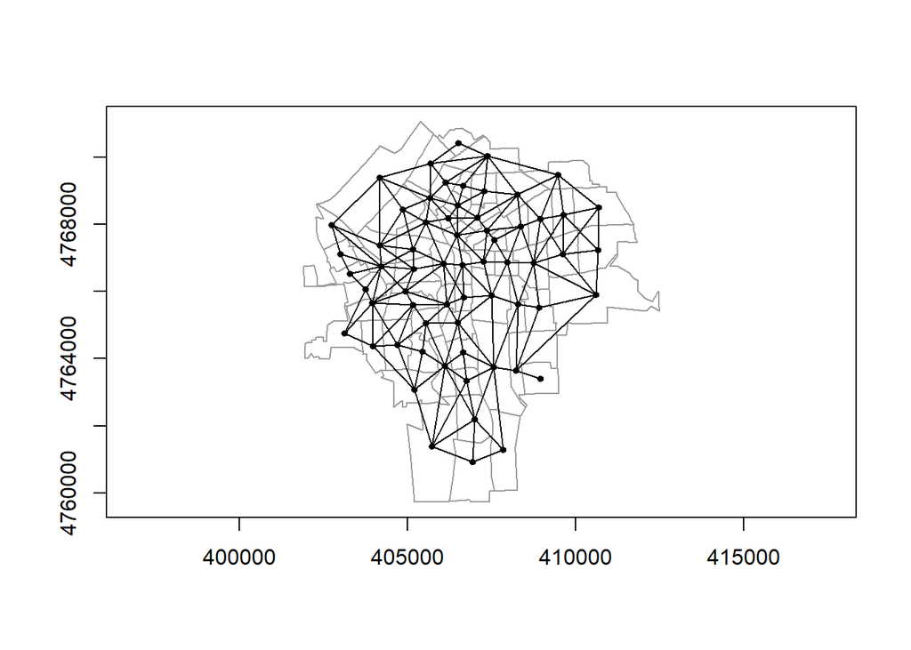

```r
plot(st_geometry(Syracuse), border = 'grey60', axes = T)
plot(Sy0_nb, st_geometry(Syracuse), pch = 19, cex = 0.6, add = T)
```

Las relaciones entre *n* observaciones vecinas (regiones) son representadas por un objeto de clase *nb*. Estos objetos son una lista de longitud *n* con el índice de la región y un vector de enteros con los vecinos de cada región (índices). Si una región (polígono) no tiene vecinos, el componente tendrá un 0.

El objeto de clase *nb* (NY_nb) tiene incluidos métodos de `print`, `summary` y `plot` entre otros.

Summary presenta una tabla de la distribución del número de enlaces y reporta asimetría y presencia de observaciones no vecinas.

```r
summary(Sy0_nb)
```

```
## Neighbour list object:
## Number of regions: 63
## Number of nonzero links: 346
## Percentage nonzero weights: 8.717561
## Average number of links: 5.492063
## Link number distribution:
##
##  1  2  3  4  5  6  7  8  9
##  1  1  5  9 14 17  9  6  1
## 1 least connected region:
## 164 with 1 link
## 1 most connected region:
## 136 with 9 links
```

> La asimetria está presente cuando *i* es un vecino de *j*, pero *j* no es un vecino de *i*.

El resultados de la función `summary` brinda información acerca de:

- El número de regiones (polígonos) en la base de datos: 63
- El número de relaciones diferentes de 0: 346
- El porcentaje de pesos distinto de 0: 8.717561
- El número promedio de relaciones entre los polígonos: 5.492063

Se observa también la distribución de las relaciones que indican que el número máximo de vecinos que se encontraron fueron 9 y estuvieron con respecto a un poligono, 17 de las 63 regiones presentes tienen 6 uniones, etc.

```r
card(Sy0_nb)
```

```
##  [1] 5 5 2 7 7 5 4 5 7 5 5 7 5 7 6 6 6 6 6 4 4 7 6 8 4 3 3 9 6 8 6 6 6 8 6 4 4 8
## [39] 6 6 7 5 7 6 4 5 3 5 6 4 6 7 4 8 5 1 5 8 5 5 6 3 3
```

La función `card` permite obtener de forma rápida el número de vecinos de cada región.

Se crearán objetos de lista de vecinos para uso posterior en el documento, para esto se utiliza la función `knearneigh` para obtener el índice de los puntos de *k* vecinos cercanos, esta función recibe como parametro de ingreso la lista de coordenadas de los puntos y un valor *k* que indica el número de puntos vecinos cercanos que se desean retornar. El resultado de la operación anterior se ingresa a la función `knn2nb` para convertir el objeto resultante en una lista de vecinos de la clase *nb*.

```r
coords <- st_point_on_surface(st_geometry(Syracuse))
ids <- row.names(Syracuse)
Sy8_nb <- knn2nb(knearneigh(coords, k = 1), row.names = ids)
Sy8_nb
```

```
## Neighbour list object:
## Number of regions: 63
## Number of nonzero links: 63
## Percentage nonzero weights: 1.587302
## Average number of links: 1
## Non-symmetric neighbours list
```

la función `nbdists` obtiene las distancias entre los puntos de los objectos vecinos calculados en el paso anterior. Esto es util porque con ella se obtiene **la distancia minima necesaria para asegurar que todas las áreas tengan al menos un vecino**.

Posteriormente se utiliza la función `dnearneigh` para obtener la lista de objetos vecinos (nb) que se encuentran a una determinada distancia (*d1*, *d2*).

```r
dsts <- unlist(nbdists(Sy8_nb, coords))
Sy11_nb <- dnearneigh(x = coords, d1 = 0, d2 = 0.75*max(dsts))
Sy11_nb
```

```
## Neighbour list object:
## Number of regions: 63
## Number of nonzero links: 156
## Percentage nonzero weights: 3.930461
## Average number of links: 2.47619
## 8 regions with no links:
## 1 10 20 36 46 57 60 61
```

Como resultado, se observa que existen 8 regiones que no poseen vecinos (1, 10, 20…).

# Objetos espaciales ponderados

Los pesos espaciales se pueden ver como una lista de pesos indexados por una lista de vecinos, donde el peso de la relación entre *i* e *j* es el k-ésimo elemento del i-ésimo componente de la lista de pesos.

La función `nb2listw` toma un objeto de lista de vecinos (nb) y lo convierte en un objeto de pesos. La conversión por defecto es *W*, donde los pesos varian entre la unidad dividido por el más largo y el más pequeño número de vecinos y la suma de los pesos para cada entidad de área es la unidad.

```r
Sy0_lw_w <- nb2listw(neighbours = Sy0_nb)
Sy0_lw_w
```

```
## Characteristics of weights list object:
## Neighbour list object:
## Number of regions: 63
## Number of nonzero links: 346
## Percentage nonzero weights: 8.717561
## Average number of links: 5.492063
##
## Weights style: W
## Weights constants summary:
##    n   nn S0       S1      S2
## W 63 3969 63 24.78291 258.564
```

Otro tipo de conversión se obtiene al configurar *style = B*, con lo cual se obtiene un peso de 1 por cada relación vecina, pero en este caso, la suma de los pesos para áreas difieren de acuerdo al número de vecinos que las áreas tengan.

> Se recomienda utilizar pesos binarios cuando se tiene poco conocimiento acerca del proceso que se está estudiando.

```r
try(
  expr = {
    nb2listw(neighbours = Sy11_nb, style = 'B', zero.policy = F)
  }
)
```

```
## Error in nb2listw(neighbours = Sy11_nb, style = "B", zero.policy = F) :
##   Empty neighbour sets found
```

Cuando existen regiones sin vecinos es necesario especificar el argumento `zero.policy = T` para que no arroje error.

```r
Sy0_lw_D1 <- nb2listw(neighbours = Sy11_nb, style = 'B', zero.policy = T)
print(Sy0_lw_D1, zero.policy = T)
```

```
## Characteristics of weights list object:
## Neighbour list object:
## Number of regions: 63
## Number of nonzero links: 156
## Percentage nonzero weights: 3.930461
## Average number of links: 2.47619
## 8 regions with no links:
## 1 10 20 36 46 57 60 61
##
## Weights style: B
## Weights constants summary:
##    n   nn  S0  S1   S2
## B 55 3025 156 312 2240
```

# Evaluando la autocorrelación espacial

Hay dos tipos de test de autocorrelación espacial que se aplican a este tipo de datos:

- Test globales: Se utilizan para verificar si existe autocorrelación espacial entre dos o más regiones en algún lugar del área de estudio (no se especifica donde).
- Test locales: Detectan clusters de vecinos con observaciones muy diferentes de los vecinos en general. Encuentran hotspots.

## Test globales

### Test de Moran I

Es la forma más común de abordar la autocorrelación espacial. Se calcula como la razón del producto de la variable de interés y su rezago espacial, con el producto cruzado de la variable de interés y ajustada por los pesos espaciales usados.

$$I = \frac{n}{\sum_{i=1}^{n}
\sum_{j=1}^{n} w_{ij}}\ \frac{\sum_{i=1}^{n} \sum_{j=1}^{n} (y_i -
\bar{y})(y_j - \bar{y})}{\sum_{i=1}^{n} (y_i - \bar{y})^2}$$
donde:

- $y_i$: Es la $ith$ observación
- $\bar{y}$: Es la media de la variable de interés
- $w_{ij}$: Es la ponderación espacial de las relaciones entre *i* e *j*.

Centrarse en la media es equivale a afirmar que el modelo correcto tiene una media constante, y que cualquier patrón restante después del centrado es causado por las relaciones espaciales codificadas en los pesos espaciales.

Para esto, se calcula la esperanza como:

$$E(I) = \frac{-1}{n-1}$$

El siguiente paso es tomar el valor observado y restarlo al valor esperado analíticamente (I - E(I)) para finalmente dividirlo por la raíz cuadrada de la varianza analítica. El resultado es comparado con la distribución normal para encontrar el valor de probabilidad del estadístico observado bajo la **hipótesis nula de ausencia de dependencia espacial para los pesos espaciales elegidos**. Los resultados pueden depender de la elección de las ponderaciones, de los vecindarios y de que los supuestos sean cumplidos.

$$H_0: Ausencia \ de \ dependencia \
espacial$$
$$H_1: El \ estadístico \
observado \ es \ significativamente \ más \ grande \ que \ el \ valor \
esperado$$

El dominio del I de Moran es [-1, 1]. Se evidencia autocorrelación espacial positiva cuando I > 0. Esto quiere decir que las unidades de análisis vecinas tienden a ser similares.

```r
moran.test(x = ny$Cases, listw = nb2listw(NY_nb))
```

```
##
##  Moran I test under randomisation
##
## data:  ny$Cases
## weights: nb2listw(NY_nb)
##
## Moran I statistic standard deviate = 3.9778, p-value = 3.477e-05
## alternative hypothesis: greater
## sample estimates:
## Moran I statistic       Expectation          Variance
##       0.146882990      -0.003571429       0.001430595
```

Por defecto, el `moran.test` usa el supuesto de aleatorización lo que difiere del supuesto de normalidad más simple al introducir un término de corrección basado en la curtosis de la variable de interés. Cuando la curtosis corresponde a la de una variable con distribución normal, las dos suposiciones arrojan la misma varianza, pero a medida que la variable se aleja de la normalidad, la suposición de aleatorización compensa aumentando la varianza y disminuyendo la desviación estándar.

```r
moran.test(x = ny$Cases, listw = nb2listw(NY_nb), randomisation = F)
```

```
##
##  Moran I test under normality
##
## data:  ny$Cases
## weights: nb2listw(NY_nb)
##
## Moran I statistic standard deviate = 3.9731, p-value = 3.547e-05
## alternative hypothesis: greater
## sample estimates:
## Moran I statistic       Expectation          Variance
##       0.146882990      -0.003571429       0.001433975
```

En este caso, se observa que la varianza no cambia, por lo tanto, el supuesto de normalidad se cumple.

Es posible también realizar test de Monte Carlo para evaluar la hipótesis de dependencia espacial con el test de Moran I.

```r
moran.mc(x = ny$Cases, listw = nb2listw(NY_nb), nsim = 999)
```

```
##
##  Monte-Carlo simulation of Moran I
##
## data:  ny$Cases
## weights: nb2listw(NY_nb)
## number of simulations + 1: 1000
##
## statistic = 0.14688, observed rank = 1000, p-value = 0.001
## alternative hypothesis: greater
```

## Test locales

Conociendo las medidas globales de asociación espacial, es posible descomponer estas medidas con el fin de construir test locales que buscan detectar clusters (Observaciones con vecinos muy similares) y hotspots (Observaciones con vecinos muy diferentes), además se pueden utilizar para conocer el impacto de los estadísticos individuales en sus contrapartes globales.

El gráfico de dispersión de Moran por convención posiciona la variable de interés en el eje x y los valores de rezago espacial (La suma de valores de los vecinos espacialmente ponderada) en el eje y. El índice global de Moran es una relación lineal entre estos valores y es dibujado como la pendiente.

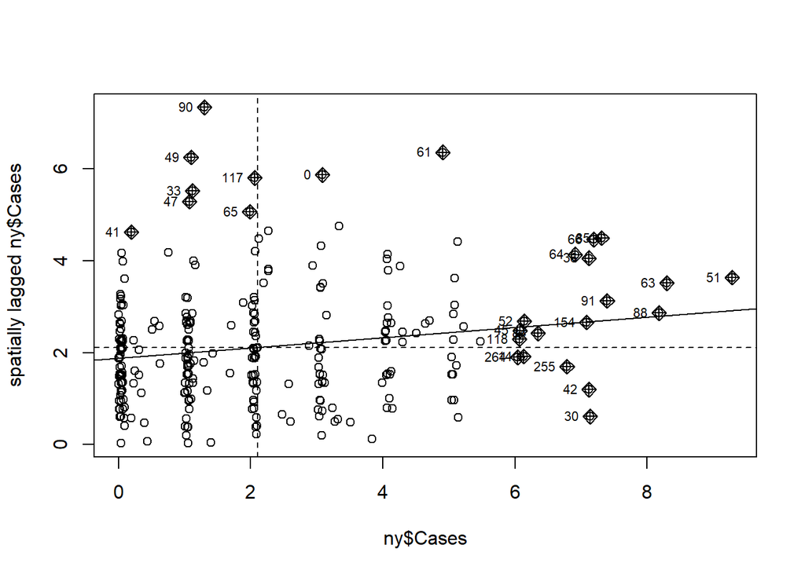

```r
moran.plot(ny$Cases, listw = nb2listw(NY_nb, style = 'C'))
```

El gráfico se divide en 4 cuadrantes. El cuadrante de la esquina superior derecha indica áreas que tienen un alta incidencia de casos de leucemia y están rodeadas por otras áreas que tienen nivel superior al promedio de casos (high-high). En la esquina inferior izquierda se encuentran áreas con baja incidencia de casos de leucemia rodeadas por áreas con incidencia de leucemia por debajo del promedio (low-low). Las áreas high-high son conocidas como hotspots y las áreas low-low como coldspots. En la diagonal opuesta se tienen valores atípicos espaciales, que indica que son áreas que están rodeadas por vecinos muy diferentes a ellos.

Los valores locales del índice de Moran se construyen como los n componentes sumados para alcanzar el índice de Moran global.

$$I_i = \frac{(y_i - \bar{y}) \sum_{j=1}^n
w_{ij}(y_j - \bar{y})}{\frac{\sum_{i = 1}^n (y_i -
\bar{y})^2}{n}}$$

Al igual que en el caso de la estadística global, se puede comprobar la divergencia de los estadísticos locales de los valores esperados, bajo los supuestos de normalidad y aleatoriedad analíticamente y usando métodos como el de punto de silla y exacto.

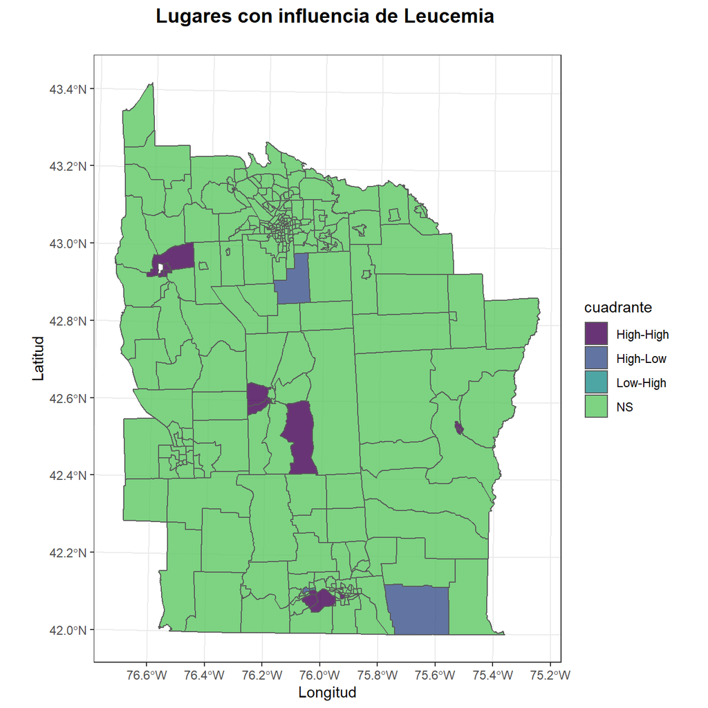

```r
library(ggplot2)
local <- as.data.frame(localmoran(ny$Cases, listw = nb2listw(NY_nb, style = "C")))
local2 <- as.data.frame(localmoran.sad(lm(Cases ~ 1, ny), nb = NY_nb, style = "C"))
local3 <- as.data.frame(localmoran.exact(lm(Cases ~ 1, ny), nb = NY_nb, style = "C"))

ny%>%
  select(Cases)%>%
  mutate(p_value = local3$`Pr. (exact)`,
         rezago = lag.listw(nb2listw(NY_nb, style = "B"), Cases),
         cuadrante = case_when(
           (Cases > mean(Cases)) & (rezago > mean(rezago)) & (p_value <= 0.05) ~ 'High-High',
           (Cases <= mean(Cases)) & (rezago <= mean(rezago)) & (p_value <= 0.05) ~ 'Low-Low',
           (Cases > mean(Cases)) & (rezago <= mean(rezago)) & (p_value <= 0.05) ~ 'High-Low',
           (Cases <= mean(Cases)) & (rezago > mean(rezago)) & (p_value <= 0.05) ~ 'Low-High',
           TRUE ~'NS'
         )) -> resultados

ggplot(resultados)+
  geom_sf(aes(fill = cuadrante), alpha = 0.8)+
  scale_fill_manual(values = viridisLite::viridis(5))+
  labs(title = 'Lugares con influencia de Leucemia \n',
       x = 'Longitud', y = 'Latitud')+
  theme_bw()+
  theme(plot.title  = element_text(size = 14, face = 'bold', hjust = 0.5))
```

Se puede calcular una evaluación de riesgo constante asumiendo una distribución Poisson con un valor de $\lambda$ igual a la probabilidad de ocurrencia de la enfermedad, se estandariza la variable tomando la propiedad de que tanto la media como la desviación estandar son iguales en esta distribución, se calculan los rezagos y se compara el indice de morán actual con el de riesgo constante.

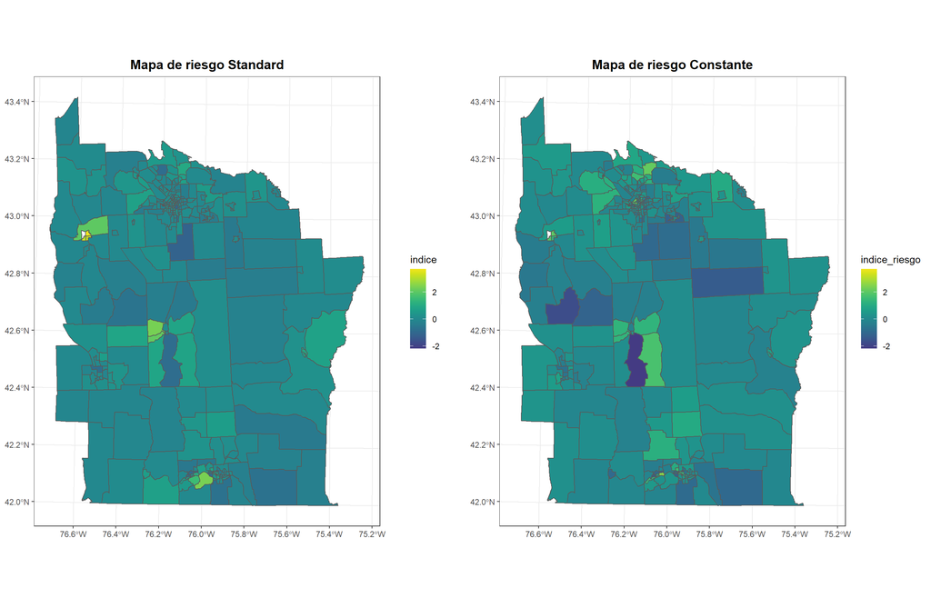

```r
ny %>%
  transmute(p_afectada = sum(Cases)/sum(POP8)*POP8,
            casos_std = (Cases - p_afectada)/sqrt(p_afectada),
            rezago = stats::lag(nb2listw(NY_nb, style = 'C'), casos_std),
            indice_riesgo = casos_std * rezago,
            indice = local$Ii) -> riesgo

m_riesgo <- ggplot(riesgo)+
  geom_sf(aes(fill = indice_riesgo))+
  labs(title = 'Mapa de riesgo Constante')+
  scale_fill_gradientn(colours = viridisLite::viridis(20, begin = 0.17,
                                                      end = 0.98),
                       limits = c(-2.2, 3.7)) +
  theme_bw()+
  theme(plot.title  = element_text(size = 14, face = 'bold', hjust = 0.5))

m_actual <- ggplot(riesgo)+
  geom_sf(aes(fill = indice))+
  labs(title = 'Mapa de riesgo Standard')+
  scale_fill_gradientn(colours = viridisLite::viridis(20, begin = 0.17,
                                                      end = 0.98),
                       limits = c(-2.2, 3.7)) +
  theme_bw() +
  theme(plot.title  = element_text(size = 14, face = 'bold', hjust = 0.5))

cowplot::plot_grid(m_actual, m_riesgo, align = 'hv', ncol = 2)
```